# Projekt CV

Kacper Ludwiczak

2023-03-14

# Regression Model Projekt - Kacper Ludwiczak, 221303

## Temat - Kształtowanie się oczekiwanej długości życia dla większości państw świata na podstawie modelu regresji i czynniki wpływające na jego wysokość.

Zaczynając projekt pracowałem na danych związanych z nowoczesnymi technologiami. Dokonałem czyszczenia danych, obliczeń w excelu oraz obliczeń w języku R. Projekty znajdują się pod nazwą “Stary projekt - Reggresion Models”, “Stary projekt – Zestawienie”, “Stary projekt w R”. Jednakże stwierdziłem, że wyniki nie są zadowalające i porzuciłem ten projekt.

Następnie zacząłem prace nad tym modelem. Dane pozyskałem ze strony kaggle.com. Według strony dane pochodzą ze strony internetowej WHO i ONZ z pomocą Deeksha Russella i Duana Wanga. Dane dotyczą większości państw świata, ich różnych zbiorów informacji, np. Długość życia. Plik z oryginałem danych jest pod nazwą “Life Expectancy Data”.

[Link do strony z oryginalnymi danymi](https://www.kaggle.com/datasets/kumarajarshi/life-expectancy-who?resource=download)

Po pierwsze chciałem skupić się na próbie 30 krajów. Wybrałem zatem 30 krajów, metodą losową. Dane obliczyłem zarówno w excelu jak i w języku R. Dane i obliczenia znajdują się w pliku “Projekt w R próba” oraz “Projekt w Excel próba”.

Uznałem, że lepszym pomysłem będzie stworzenie modelu z większości krajów na jakich dano było mi pracować. Zacząłem od pozostawienia tylko krajów z 2015 jako najbardziej aktualnych z danej bazy. Dane są pod nazwą “Dane z 2015”. Następnie zamieniłem dane za pomocą funkcji “Tekst jako kolumny”. Usunąłem kolumny “Year”, “Status”, ponieważ kolumny są mi niepotrzebne. Usunąłem kolumny “Alcohol”, “percentage expenditure”, “Total expenditure”, ponieważ były zauważające braki danych. Usunąłem kolumny “BMI”, “HIV/AIDS”, “thinness 1-19 years”, “thinness 5-9 years”, “Schooling”, ponieważ pojawiła mi się pewna anomalia. Podczas zamiany na kolumny niektóre dane są formacie daty, po zamienieniu ich na liczby pojawiały się błędne liczby. Również nie które liczby zamienione automatycznie są błędne. Po wielu nieudanych próbach rozwiązania tego problemu, dokonałem eliminacji tych kolumn. Również musiałem dokonać zamiany kropek na przecinki w liczbach oraz wypełnić puste pola średnią z reszty kolumny. Dane znajdują się w pliku “Dane zrobione”. Również stworzyłem osobny plik dla importowania do RStudio, pod nazwą “Dane do R”.

### Szczegóły dotyczące danych:

- Country - Kraj
- Year - Rok
- Status - Stan rozwinięty lub rozwijający się
- Life expectancy - Oczekiwana długość życia w latach
- Adult Mortality - Wskaźniki śmiertelności dorosłych obu płci (prawdopodobieństwo śmierci w wieku od 15 do 60 lat na 1000 mieszkańców)
- Infant deaths - Liczba zgonów niemowląt na 1000 ludności
- Alcohol - Spożycie alkoholu na mieszkańca (15+) (w litrach czystego alkoholu)
- Hepatitis B - Zasięg szczepień przeciw wirusowemu zapaleniu wątroby typu B (HepB) wśród 1-latków (%)
- Measles – Odra, liczba zgłoszonych przypadków na 1000 ludności
- BMI - Średni wskaźnik masy ciała całej populacji
- Under-five deaths - Liczba zgonów poniżej piątego roku życia na 1000 mieszkańców
- Polio - Zasięg szczepień przeciw polio (Pol3) wśród 1-latków (%)
- Total expenditure - Wydatki sektora instytucji rządowych i samorządowych na zdrowie jako odsetek wydatków sektora instytucji rządowych i samorządowych ogółem (%)
- Diphtheria - Odsetek szczepień przeciwko anatoksynie błonicy i tężcowi oraz krztuścowi (DTP3) wśród 1-latków (%)
- HIV/AIDS - Zgony na 1000 żywych urodzeń HIV/AIDS (0-4 lata)
- GDP - Produkt Krajowy Brutto per capita (w USD)
- Population - Ludność kraju
- Thinness 1-19 years - Rozpowszechnienie szczupłości wśród dzieci i młodzieży w wieku od 10 do 19 lat (%)
- Thinness 5-9 years - Występowanie szczupłości wśród dzieci w wieku od 5 do 9 lat (%)
- Income - Wskaźnik rozwoju społecznego pod względem struktury dochodów zasobów (wskaźnik w zakresie od 0 do 1)
- Schooling- Liczba lat nauki (lata)

### Projekt w RStudio jest pod nazwą “Projekt R markdown”

Zainstalowałem pakiet “readxl”, oraz uruchomiłem go przez funkcje “library”.

```r
library(readxl)
```

Zainstalowałem pakiet “rmarkdown”, oraz uruchomiłem go przez funkcje “library”.

```r
library(rmarkdown)
```

Kod wczytuje plik excel “Dane do R.xlsx” i zapisuje jego zawartość w zmiennej “Dane”. Następnie wyświetla zawartość tej zmiennej za pomocą funkcji “View()”, wyświetla nazwy kolumn danych za pomocą funkcji “names()”, a na końcu wyświetla wartości kolumny “Life expectancy” za pomocą funkcji “print()”.

```r
Dane <-  read_excel("C:/Users/Kacper/Desktop/Projekt Regression/Dane do R.xlsx")
View(Dane)
names(Dane)
```

```
##  [1] "Life expectancy" "Adult Mortality" "Infant deaths"   "Hepatitis B"
##  [5] "Measles"         "Under-5 deaths"  "Polio"           "Diphtheria"
##  [9] "GDP"             "Population"      "Income"
```

```r
print(Dane$"Life expectancy" )
```

```
##   [1] 65.0 77.8 75.6 52.4 76.4 76.3 74.8 82.8 81.5 72.7 76.1 76.9 71.8 75.5 72.3
##  [16] 81.1 71.0 60.0 69.8 77.0 77.4 65.7 75.0 77.7 74.5 59.9 59.6 73.3 68.7 57.3
##  [31] 82.2 52.5 53.1 85.0 76.1 74.8 63.5 64.7 79.6 78.0 79.1 85.0 78.8 76.0 59.8
##  [46] 86.0 63.5 73.9 76.2 79.0 73.5 58.2 64.7 77.6 64.8 69.9 81.1 82.4 66.0 61.1
##  [61] 74.4 81.0 62.4 81.0 73.6 71.9 59.0 58.9 66.2 63.5 74.6 75.8 82.7 68.3 69.1
##  [76] 75.5 68.9 81.4 82.5 82.7 76.2 83.7 74.1 72.0 63.4 66.3 74.7 71.1 65.7 74.6
##  [91] 74.9 53.7 61.4 72.7 73.6 82.0 65.5 58.3 75.0 78.5 58.2 81.7 63.1 74.6 76.7
## [106] 69.4 68.8 76.1 74.3 57.6 66.6 65.8 69.2 81.9 81.6 74.8 61.8 54.5 81.8 76.6
## [121] 66.4 77.8 62.9 74.0 75.5 68.5 77.5 81.1 78.2 82.3 72.1 75.0 75.0 66.1 75.2
## [136] 73.2 74.0 67.5 74.5 66.7 75.6 73.2 51.0 83.1 76.7 88.0 69.2 55.0 62.9 57.3
## [151] 82.8 74.9 64.1 71.6 58.9 82.4 83.4 64.5 69.7 74.9 75.7 68.3 59.9 73.5 71.2
## [166] 75.3 75.8 66.3 62.3 71.3 77.1 81.2 61.8 79.3 77.0 69.4 72.0 74.1 76.0 65.7
## [181] 61.8 67.0
```

Tutaj za pomocą funkcji “colnames” dokonałem zmiany nazw kolumn w celu szybszej pracy w dalszych etapach.

```r
colnames(Dane)<-c("Life","Adult_M","Infant_D","H_B","Measles","Under_D","Polio","Dipht","GDP","Popl","Income")
```

Użyłem funkcji “plot” w celu zobaczeniu na wykresie dane z kolumny “Life”. Kolumna “Life” zostaje moją zmienną zależną, natomiast reszta kolumn zmiennymi niezależnymi.

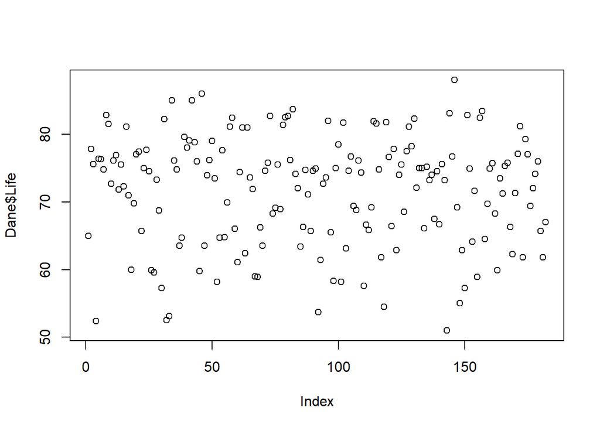

```r
plot(Dane$"Life")
```

Sprawdziłem następujące wartości danych: * Minimalna wartość = 51.00 * Pierwszy kwartal = 65.85 * Mediana = 73.95 * Średnia = 71.72 * Trzeci kwartal = 76.97 * Maksymalna wartość = 88.00 , dla zmiennej zależnej.

```r
summary(Dane$"Life" )
```

```
##    Min. 1st Qu.  Median    Mean 3rd Qu.    Max.
##   51.00   65.85   73.95   71.72   76.97   88.00
```

W celu zobrazowania graficznego użyłem funkcji “hist”. Według tego można zauważyć dominacje wartości w przedziale od 70 do 80.

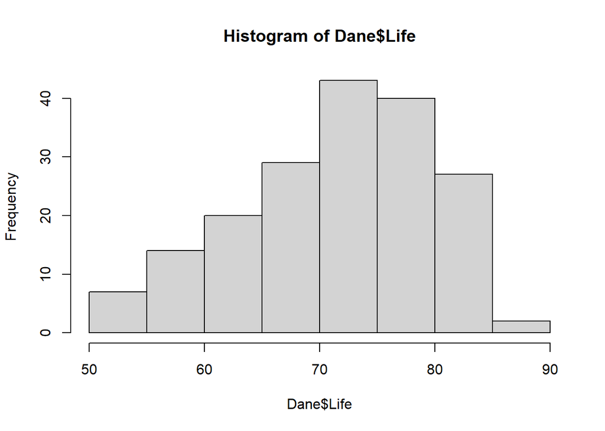

```r
hist(Dane$"Life" )
```

Za pomocą funkcji “cor” przedstawiłem korelacje wszystkich zmiennych. Im dana liczba jest większa tym większa jest korelacja między odpowiadającymi danymi w wierszu i kolumnie. Można z niej ustalić, że korelacja między zmienną zależną “Life” a zmienną: * “Adult_M” jest duża ujemnie * “Infant_D” jest bardzo mała ujemnie * “H_B” jest mała dodatnio * “Measles” jest bardzo mała ujemnie * “Under_D” jest bardzo mała ujemnie * “Polio” jest średnia dodatnio * “Dipht” jest średnia dodatnio * “GDP” jest mała dodatnio * “Popl” jest bardzo mała ujemnie * “Income” jest bardzo mała ujemnie

```r
cor(Dane)
```

```
##                 Life     Adult_M    Infant_D         H_B      Measles
## Life      1.00000000 -0.77215206 -0.23984305  0.40450050 -0.077810464
## Adult_M  -0.77215206  1.00000000  0.18604690 -0.23139939  0.054570792
## Infant_D -0.23984305  0.18604690  1.00000000 -0.08681527  0.801663443
## H_B       0.40450050 -0.23139939 -0.08681527  1.00000000  0.015656414
## Measles  -0.07781046  0.05457079  0.80166344  0.01565641  1.000000000
## Under_D  -0.27495588  0.21446481  0.99348313 -0.11001898  0.764990118
## Polio     0.52186030 -0.37773277 -0.12958871  0.59020367 -0.028359472
## Dipht     0.50655358 -0.32738699 -0.11788072  0.90925537 -0.001622602
## GDP       0.43089742 -0.31610931 -0.11953200  0.13188477 -0.076143290
## Popl     -0.04721323  0.03756295  0.26624483 -0.05672244  0.127925269
## Income   -0.13196089  0.13031897  0.02150182 -0.08670694  0.008493532
##              Under_D       Polio        Dipht         GDP         Popl
## Life     -0.27495588  0.52186030  0.506553583  0.43089742 -0.047213234
## Adult_M   0.21446481 -0.37773277 -0.327386992 -0.31610931  0.037562946
## Infant_D  0.99348313 -0.12958871 -0.117880715 -0.11953200  0.266244826
## H_B      -0.11001898  0.59020367  0.909255374  0.13188477 -0.056722444
## Measles   0.76499012 -0.02835947 -0.001622602 -0.07614329  0.127925269
## Under_D   1.00000000 -0.15154462 -0.143729736 -0.12620291  0.303720175
## Polio    -0.15154462  1.00000000  0.661623315  0.22349572 -0.221071926
## Dipht    -0.14372974  0.66162332  1.000000000  0.21333277 -0.065038775
## GDP      -0.12620291  0.22349572  0.213332775  1.00000000  0.046037030
## Popl      0.30372017 -0.22107193 -0.065038775  0.04603703  1.000000000
## Income    0.05419071 -0.06262976 -0.100745256 -0.04756283 -0.007033844
##                Income
## Life     -0.131960889
## Adult_M   0.130318973
## Infant_D  0.021501816
## H_B      -0.086706940
## Measles   0.008493532
## Under_D   0.054190707
## Polio    -0.062629761
## Dipht    -0.100745256
## GDP      -0.047562832
## Popl     -0.007033844
## Income    1.000000000
```

Kod ten oblicza korelację między kolumnami w obiekcie “Dane”, z wyjątkiem pierwszej kolumny, która jest pomijana za pomocą wyrażenia “[, -1]”. Jest to kolumna “Life”. Funkcja “cor” oblicza korelację Pearsona, czyli stopień zależności liniowej między dwoma zmiennymi. Wynik jest następnie zaokrąglany do trzech miejsc po przecinku za pomocą funkcji “round”.

```r
round(cor(Dane[,-1]),3)
```

```
##          Adult_M Infant_D    H_B Measles Under_D  Polio  Dipht    GDP   Popl
## Adult_M    1.000    0.186 -0.231   0.055   0.214 -0.378 -0.327 -0.316  0.038
## Infant_D   0.186    1.000 -0.087   0.802   0.993 -0.130 -0.118 -0.120  0.266
## H_B       -0.231   -0.087  1.000   0.016  -0.110  0.590  0.909  0.132 -0.057
## Measles    0.055    0.802  0.016   1.000   0.765 -0.028 -0.002 -0.076  0.128
## Under_D    0.214    0.993 -0.110   0.765   1.000 -0.152 -0.144 -0.126  0.304
## Polio     -0.378   -0.130  0.590  -0.028  -0.152  1.000  0.662  0.223 -0.221
## Dipht     -0.327   -0.118  0.909  -0.002  -0.144  0.662  1.000  0.213 -0.065
## GDP       -0.316   -0.120  0.132  -0.076  -0.126  0.223  0.213  1.000  0.046
## Popl       0.038    0.266 -0.057   0.128   0.304 -0.221 -0.065  0.046  1.000
## Income     0.130    0.022 -0.087   0.008   0.054 -0.063 -0.101 -0.048 -0.007
##          Income
## Adult_M   0.130
## Infant_D  0.022
## H_B      -0.087
## Measles   0.008
## Under_D   0.054
## Polio    -0.063
## Dipht    -0.101
## GDP      -0.048
## Popl     -0.007
## Income    1.000
```

Kod ten tworzy macierz z danych zawartych w obiekcie “Dane”. Wiersze z obiektu “Dane” są wczytywane za pomocą wyrażenia “[, -1]”, co oznacza, że pierwsza kolumna jest pomijana. Jest to kolumna “Life”. Następnie dane są konwertowane na macierz za pomocą funkcji “as.matrix”. Ostatecznie macierz jest przypisywana do obiektu “matrix”.

```r
matrix <- as.matrix(Dane[,-1])
```

Kod oblicza własne wartości i wektory dla macierzy “matrix”. Macierz jest najpierw transponowana za pomocą funkcji “t”, a następnie mnożona przez siebie za pomocą operatora “%*%“, co daje macierz kowariancji. Otrzymaną macierz kowariancji jest analizowana przez funkcję”eigen”, która oblicza własne wartości i wektory. Wynik jest przypisywany do obiektu “matrix_eigen”. Dzięki temu mogę zobaczyć własne wartości macierzy

```r
matrix_eigen <- eigen(t(matrix) %*% matrix)
matrix_eigen$val
```

```
##  [1] 1.365373e+17 2.887223e+10 1.122436e+10 6.501808e+06 1.227256e+06
##  [6] 7.446202e+05 4.555312e+04 1.774313e+04 7.863299e+03 5.388979e+03
```

```r
sqrt(matrix_eigen$val[1]/matrix_eigen$val)
```

```
##  [1]       1.000    2174.631    3487.746  144913.411  333547.800  428211.415
##  [7] 1731277.043 2774026.198 4166997.596 5033527.140
```

Sprawdziłem na wykresie jaka jest korelacje zmiennej zależnej i zmiennej “Adult_M” w postaci graficznej. Tutaj przetestowałem funkcje “lm” za pomocą stworzenia modelu prostej regresji liniowej z użyciem jednej zmiennej niezależnej. Funkcja “abline” umożliwiła mi dodanie niebieskiej linii regresji, która najdokładniej próbuje dopasować się do istniejących danych. Można zauważyć, że linia jest przekrzywiona w dół po stronie lewej, wynika to z pojawiających się wartości odstających, poniżej wartości 100 dla zmiennej niezależnej.

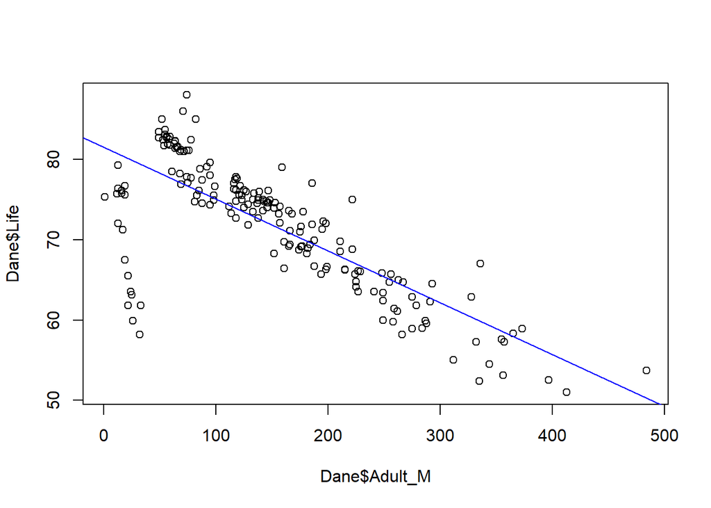

```r
plot(Dane$"Life"~Dane$"Adult_M")
SimpleModel<- lm(Dane$"Life"~Dane$"Adult_M")
abline(SimpleModel$coef,col="blue")
```

Wynik p-value wyszedł bardzo dobry. Jednakże wartość R-squared zbyt mała.

```r
summary(SimpleModel)
```

```
##
## Call:
## lm(formula = Dane$Life ~ Dane$Adult_M)
##
## Residuals:
##      Min       1Q   Median       3Q      Max
## -21.2282  -1.6823   0.7664   2.9876  11.2813
##
## Coefficients:
##               Estimate Std. Error t value Pr(>|t|)
## (Intercept)  81.492535   0.709494   114.9   <2e-16 ***
## Dane$Adult_M -0.064512   0.003957   -16.3   <2e-16 ***
## ---
## Signif. codes:  0 '***' 0.001 '**' 0.01 '*' 0.05 '.' 0.1 ' ' 1
##
## Residual standard error: 5.117 on 180 degrees of freedom
## Multiple R-squared:  0.5962, Adjusted R-squared:  0.594
## F-statistic: 265.8 on 1 and 180 DF,  p-value: < 2.2e-16
```

Stworzenie pierwszego modelu. Używam metody “Backward” ręcznie. Eliminując zmienne o najwyższym wskaźniku p-value, tak długo aż model będzie zadawalający. Zakładam dla modelu, że poziom p-value poniżej 0.05 jest odpowiedni.

```r
Model <- lm(Life~Adult_M+Infant_D+H_B+Measles+Under_D+Polio+Dipht+GDP+Popl+Income,data=Dane)
summary(Model)
```

```
##
## Call:
## lm(formula = Life ~ Adult_M + Infant_D + H_B + Measles + Under_D +
##     Polio + Dipht + GDP + Popl + Income, data = Dane)
##
## Residuals:
##      Min       1Q   Median       3Q      Max
## -16.3833  -2.4605   0.2957   2.3275  11.8063
##
## Coefficients:
##               Estimate Std. Error t value Pr(>|t|)
## (Intercept)  6.931e+01  1.761e+00  39.356  < 2e-16 ***
## Adult_M     -4.718e-02  3.959e-03 -11.919  < 2e-16 ***
## Infant_D     9.576e-02  4.644e-02   2.062 0.040728 *
## H_B         -9.270e-03  3.379e-02  -0.274 0.784131
## Measles      1.253e-05  7.851e-05   0.160 0.873375
## Under_D     -8.295e-02  3.440e-02  -2.412 0.016940 *
## Polio        5.024e-02  1.887e-02   2.662 0.008500 **
## Dipht        6.339e-02  3.886e-02   1.631 0.104718
## GDP          1.202e-04  3.239e-05   3.712 0.000278 ***
## Popl         2.531e-08  1.461e-08   1.732 0.085120 .
## Income       1.122e-02  3.531e-02   0.318 0.751148
## ---
## Signif. codes:  0 '***' 0.001 '**' 0.01 '*' 0.05 '.' 0.1 ' ' 1
##
## Residual standard error: 4.346 on 171 degrees of freedom
## Multiple R-squared:  0.7233, Adjusted R-squared:  0.7071
## F-statistic: 44.69 on 10 and 171 DF,  p-value: < 2.2e-16
```

W pierwszym modelu największy poziom p-value miała kolumna “Measles”. W drugim modelu już się nie pojawiła.

```r
Model2 <- lm(Life~Adult_M+Infant_D+H_B+Under_D+Polio+Dipht+GDP+Popl+Income,data=Dane)
summary(Model2)
```

```
##
## Call:
## lm(formula = Life ~ Adult_M + Infant_D + H_B + Under_D + Polio +
##     Dipht + GDP + Popl + Income, data = Dane)
##
## Residuals:
##      Min       1Q   Median       3Q      Max
## -16.3917  -2.4905   0.3158   2.3285  11.8053
##
## Coefficients:
##               Estimate Std. Error t value Pr(>|t|)
## (Intercept)  6.930e+01  1.755e+00  39.481  < 2e-16 ***
## Adult_M     -4.721e-02  3.944e-03 -11.968  < 2e-16 ***
## Infant_D     9.971e-02  3.918e-02   2.545 0.011806 *
## H_B         -9.209e-03  3.369e-02  -0.273 0.784901
## Under_D     -8.530e-02  3.099e-02  -2.752 0.006554 **
## Polio        5.024e-02  1.882e-02   2.670 0.008305 **
## Dipht        6.345e-02  3.875e-02   1.637 0.103391
## GDP          1.201e-04  3.229e-05   3.720 0.000269 ***
## Popl         2.538e-08  1.457e-08   1.743 0.083161 .
## Income       1.204e-02  3.483e-02   0.346 0.730039
## ---
## Signif. codes:  0 '***' 0.001 '**' 0.01 '*' 0.05 '.' 0.1 ' ' 1
##
## Residual standard error: 4.334 on 172 degrees of freedom
## Multiple R-squared:  0.7232, Adjusted R-squared:  0.7087
## F-statistic: 49.94 on 9 and 172 DF,  p-value: < 2.2e-16
```

W drugim modelu największy poziom p-value miała kolumna “H_B”. W trzecim modelu już się nie pojawiła

```r
Model3 <- lm(Life~Adult_M+Infant_D+Under_D+Polio+Dipht+GDP+Popl+Income,data=Dane)
summary(Model3)
```

```
##
## Call:
## lm(formula = Life ~ Adult_M + Infant_D + Under_D + Polio + Dipht +
##     GDP + Popl + Income, data = Dane)
##
## Residuals:
##      Min       1Q   Median       3Q      Max
## -16.4264  -2.4996   0.3435   2.3178  11.8929
##
## Coefficients:
##               Estimate Std. Error t value Pr(>|t|)
## (Intercept)  6.933e+01  1.747e+00  39.684  < 2e-16 ***
## Adult_M     -4.735e-02  3.899e-03 -12.143  < 2e-16 ***
## Infant_D     9.943e-02  3.906e-02   2.546 0.011780 *
## Under_D     -8.510e-02  3.090e-02  -2.754 0.006521 **
## Polio        5.018e-02  1.876e-02   2.674 0.008208 **
## Dipht        5.437e-02  1.988e-02   2.735 0.006881 **
## GDP          1.211e-04  3.200e-05   3.785 0.000211 ***
## Popl         2.531e-08  1.452e-08   1.743 0.083134 .
## Income       1.203e-02  3.474e-02   0.346 0.729621
## ---
## Signif. codes:  0 '***' 0.001 '**' 0.01 '*' 0.05 '.' 0.1 ' ' 1
##
## Residual standard error: 4.322 on 173 degrees of freedom
## Multiple R-squared:  0.7231, Adjusted R-squared:  0.7103
## F-statistic: 56.47 on 8 and 173 DF,  p-value: < 2.2e-16
```

W trzecim modelu największy poziom p-value miała kolumna “Income”. W czwartym modelu już się nie pojawiła.

```r
Model4 <- lm(Life~Adult_M+Infant_D+Under_D+Polio+Dipht+GDP+Popl,data=Dane)
summary(Model4)
```

```
##
## Call:
## lm(formula = Life ~ Adult_M + Infant_D + Under_D + Polio + Dipht +
##     GDP + Popl, data = Dane)
##
## Residuals:
##      Min       1Q   Median       3Q      Max
## -16.4750  -2.5123   0.3676   2.3051  11.8873
##
## Coefficients:
##               Estimate Std. Error t value Pr(>|t|)
## (Intercept)  6.935e+01  1.742e+00  39.819  < 2e-16 ***
## Adult_M     -4.730e-02  3.887e-03 -12.169  < 2e-16 ***
## Infant_D     9.561e-02  3.737e-02   2.558 0.011365 *
## Under_D     -8.206e-02  2.955e-02  -2.777 0.006095 **
## Polio        5.021e-02  1.872e-02   2.683 0.008003 **
## Dipht        5.425e-02  1.982e-02   2.737 0.006843 **
## GDP          1.211e-04  3.192e-05   3.795 0.000203 ***
## Popl         2.472e-08  1.439e-08   1.718 0.087513 .
## ---
## Signif. codes:  0 '***' 0.001 '**' 0.01 '*' 0.05 '.' 0.1 ' ' 1
##
## Residual standard error: 4.312 on 174 degrees of freedom
## Multiple R-squared:  0.7229, Adjusted R-squared:  0.7118
## F-statistic: 64.85 on 7 and 174 DF,  p-value: < 2.2e-16
```

W czwartym modelu największy poziom p-value miała kolumna “Popl”. W piątym modelu już się nie pojawiła.

```r
Model5 <- lm(Life~Adult_M+Infant_D+Under_D+Polio+Dipht+GDP,data=Dane)
summary(Model5)
```

```
##
## Call:
## lm(formula = Life ~ Adult_M + Infant_D + Under_D + Polio + Dipht +
##     GDP, data = Dane)
##
## Residuals:
##     Min      1Q  Median      3Q     Max
## -16.951  -2.437   0.477   2.551  11.735
##
## Coefficients:
##               Estimate Std. Error t value Pr(>|t|)
## (Intercept)  6.980e+01  1.731e+00  40.319  < 2e-16 ***
## Adult_M     -4.821e-02  3.872e-03 -12.451  < 2e-16 ***
## Infant_D     7.326e-02  3.523e-02   2.080  0.03901 *
## Under_D     -6.291e-02  2.753e-02  -2.286  0.02347 *
## Polio        4.199e-02  1.819e-02   2.308  0.02218 *
## Dipht        5.995e-02  1.965e-02   3.051  0.00264 **
## GDP          1.264e-04  3.194e-05   3.957  0.00011 ***
## ---
## Signif. codes:  0 '***' 0.001 '**' 0.01 '*' 0.05 '.' 0.1 ' ' 1
##
## Residual standard error: 4.336 on 175 degrees of freedom
## Multiple R-squared:  0.7182, Adjusted R-squared:  0.7086
## F-statistic: 74.34 on 6 and 175 DF,  p-value: < 2.2e-16
```

W piątym modelu po usunięciu kolumny “Popl”, nastąpił duży wzrost wartości p-value dla kolumny “Under_D” oraz “Polio”. Jest efekt niepożądany dla mojego modelu, dlatego wybranym modelem zostaje model czwarty. Pomimo wartości p-value dla kolumny “Popl” w okolicy 0.08. Również poziom R-squared wynosi 0.7229, możemy interpretować to jako dobry model, choć na granicy złego (zmienność oczekiwanej długości życia jest wyjaśniony w 72% przez model). Dodatkowo Adjusted Rsquared jest na poziomie 0.7118, jest to najlepszy wynik ze wszystkich pięciu policzonych.

```r
Model <- lm(Life~Adult_M+Infant_D+Under_D+Polio+Dipht+GDP+Popl,data=Dane)
summary(Model)
```

```
##
## Call:
## lm(formula = Life ~ Adult_M + Infant_D + Under_D + Polio + Dipht +
##     GDP + Popl, data = Dane)
##
## Residuals:
##      Min       1Q   Median       3Q      Max
## -16.4750  -2.5123   0.3676   2.3051  11.8873
##
## Coefficients:
##               Estimate Std. Error t value Pr(>|t|)
## (Intercept)  6.935e+01  1.742e+00  39.819  < 2e-16 ***
## Adult_M     -4.730e-02  3.887e-03 -12.169  < 2e-16 ***
## Infant_D     9.561e-02  3.737e-02   2.558 0.011365 *
## Under_D     -8.206e-02  2.955e-02  -2.777 0.006095 **
## Polio        5.021e-02  1.872e-02   2.683 0.008003 **
## Dipht        5.425e-02  1.982e-02   2.737 0.006843 **
## GDP          1.211e-04  3.192e-05   3.795 0.000203 ***
## Popl         2.472e-08  1.439e-08   1.718 0.087513 .
## ---
## Signif. codes:  0 '***' 0.001 '**' 0.01 '*' 0.05 '.' 0.1 ' ' 1
##
## Residual standard error: 4.312 on 174 degrees of freedom
## Multiple R-squared:  0.7229, Adjusted R-squared:  0.7118
## F-statistic: 64.85 on 7 and 174 DF,  p-value: < 2.2e-16
```

```r
Model_backward<-step(lm(Life~Adult_M+Infant_D+H_B+Measles+Under_D+Polio+Dipht+GDP+Popl+Income,data=Dane),direction="backward")
```

```
## Start:  AIC=545.5
## Life ~ Adult_M + Infant_D + H_B + Measles + Under_D + Polio +
##     Dipht + GDP + Popl + Income
##
##            Df Sum of Sq    RSS    AIC
## - Measles   1      0.48 3230.9 543.53
## - H_B       1      1.42 3231.9 543.58
## - Income    1      1.91 3232.3 543.61
## <none>                  3230.4 545.50
## - Dipht     1     50.26 3280.7 546.31
## - Popl      1     56.66 3287.1 546.66
## - Infant_D  1     80.32 3310.8 547.97
## - Under_D   1    109.87 3340.3 549.59
## - Polio     1    133.91 3364.3 550.89
## - GDP       1    260.29 3490.7 557.60
## - Adult_M   1   2683.87 5914.3 653.56
##
## Step:  AIC=543.53
## Life ~ Adult_M + Infant_D + H_B + Under_D + Polio + Dipht + GDP +
##     Popl + Income
##
##            Df Sum of Sq    RSS    AIC
## - H_B       1      1.40 3232.3 541.60
## - Income    1      2.24 3233.2 541.65
## <none>                  3230.9 543.53
## - Dipht     1     50.36 3281.3 544.34
## - Popl      1     57.05 3288.0 544.71
## - Infant_D  1    121.67 3352.6 548.25
## - Polio     1    133.94 3364.9 548.92
## - Under_D   1    142.29 3373.2 549.37
## - GDP       1    259.99 3490.9 555.61
## - Adult_M   1   2690.72 5921.6 651.79
##
## Step:  AIC=541.6
## Life ~ Adult_M + Infant_D + Under_D + Polio + Dipht + GDP + Popl +
##     Income
##
##            Df Sum of Sq    RSS    AIC
## - Income    1      2.24 3234.6 539.73
## <none>                  3232.3 541.60
## - Popl      1     56.75 3289.1 542.77
## - Infant_D  1    121.08 3353.4 546.30
## - Polio     1    133.62 3365.9 546.98
## - Dipht     1    139.79 3372.1 547.31
## - Under_D   1    141.69 3374.0 547.41
## - GDP       1    267.74 3500.1 554.09
## - Adult_M   1   2755.08 5987.4 651.80
##
## Step:  AIC=539.73
## Life ~ Adult_M + Infant_D + Under_D + Polio + Dipht + GDP + Popl
##
##            Df Sum of Sq    RSS    AIC
## <none>                  3234.6 539.73
## - Popl      1     54.89 3289.5 540.79
## - Infant_D  1    121.68 3356.2 544.45
## - Polio     1    133.81 3368.4 545.11
## - Dipht     1    139.26 3373.8 545.40
## - Under_D   1    143.32 3377.9 545.62
## - GDP       1    267.75 3502.3 552.21
## - Adult_M   1   2752.98 5987.5 649.80
```

```r
summary(Model_backward)
```

```
##
## Call:
## lm(formula = Life ~ Adult_M + Infant_D + Under_D + Polio + Dipht +
##     GDP + Popl, data = Dane)
##
## Residuals:
##      Min       1Q   Median       3Q      Max
## -16.4750  -2.5123   0.3676   2.3051  11.8873
##
## Coefficients:
##               Estimate Std. Error t value Pr(>|t|)
## (Intercept)  6.935e+01  1.742e+00  39.819  < 2e-16 ***
## Adult_M     -4.730e-02  3.887e-03 -12.169  < 2e-16 ***
## Infant_D     9.561e-02  3.737e-02   2.558 0.011365 *
## Under_D     -8.206e-02  2.955e-02  -2.777 0.006095 **
## Polio        5.021e-02  1.872e-02   2.683 0.008003 **
## Dipht        5.425e-02  1.982e-02   2.737 0.006843 **
## GDP          1.211e-04  3.192e-05   3.795 0.000203 ***
## Popl         2.472e-08  1.439e-08   1.718 0.087513 .
## ---
## Signif. codes:  0 '***' 0.001 '**' 0.01 '*' 0.05 '.' 0.1 ' ' 1
##
## Residual standard error: 4.312 on 174 degrees of freedom
## Multiple R-squared:  0.7229, Adjusted R-squared:  0.7118
## F-statistic: 64.85 on 7 and 174 DF,  p-value: < 2.2e-16
```

```r
Model_both<-step(lm(Life~Adult_M+Infant_D+H_B+Measles+Under_D+Polio+Dipht+GDP+Popl+Income,data=Dane),direction="both")
```

```
## Start:  AIC=545.5
## Life ~ Adult_M + Infant_D + H_B + Measles + Under_D + Polio +
##     Dipht + GDP + Popl + Income
##
##            Df Sum of Sq    RSS    AIC
## - Measles   1      0.48 3230.9 543.53
## - H_B       1      1.42 3231.9 543.58
## - Income    1      1.91 3232.3 543.61
## <none>                  3230.4 545.50
## - Dipht     1     50.26 3280.7 546.31
## - Popl      1     56.66 3287.1 546.66
## - Infant_D  1     80.32 3310.8 547.97
## - Under_D   1    109.87 3340.3 549.59
## - Polio     1    133.91 3364.3 550.89
## - GDP       1    260.29 3490.7 557.60
## - Adult_M   1   2683.87 5914.3 653.56
##
## Step:  AIC=543.53
## Life ~ Adult_M + Infant_D + H_B + Under_D + Polio + Dipht + GDP +
##     Popl + Income
##
##            Df Sum of Sq    RSS    AIC
## - H_B       1      1.40 3232.3 541.60
## - Income    1      2.24 3233.2 541.65
## <none>                  3230.9 543.53
## - Dipht     1     50.36 3281.3 544.34
## - Popl      1     57.05 3288.0 544.71
## + Measles   1      0.48 3230.4 545.50
## - Infant_D  1    121.67 3352.6 548.25
## - Polio     1    133.94 3364.9 548.92
## - Under_D   1    142.29 3373.2 549.37
## - GDP       1    259.99 3490.9 555.61
## - Adult_M   1   2690.72 5921.6 651.79
##
## Step:  AIC=541.6
## Life ~ Adult_M + Infant_D + Under_D + Polio + Dipht + GDP + Popl +
##     Income
##
##            Df Sum of Sq    RSS    AIC
## - Income    1      2.24 3234.6 539.73
```

[output cut: 11 more lines]

```
## Step:  AIC=539.73
## Life ~ Adult_M + Infant_D + Under_D + Polio + Dipht + GDP + Popl
##
##            Df Sum of Sq    RSS    AIC
## <none>                  3234.6 539.73
## - Popl      1     54.89 3289.5 540.79
## + Income    1      2.24 3232.3 541.60
## + H_B       1      1.40 3233.2 541.65
## + Measles   1      0.80 3233.8 541.69
## - Infant_D  1    121.68 3356.2 544.45
## - Polio     1    133.81 3368.4 545.11
## - Dipht     1    139.26 3373.8 545.40
## - Under_D   1    143.32 3377.9 545.62
## - GDP       1    267.75 3502.3 552.21
## - Adult_M   1   2752.98 5987.5 649.80
```

```r
summary(Model_both)
```

```
##
## Call:
## lm(formula = Life ~ Adult_M + Infant_D + Under_D + Polio + Dipht +
##     GDP + Popl, data = Dane)
##
## Residuals:
##      Min       1Q   Median       3Q      Max
## -16.4750  -2.5123   0.3676   2.3051  11.8873
##
## Coefficients:
##               Estimate Std. Error t value Pr(>|t|)
## (Intercept)  6.935e+01  1.742e+00  39.819  < 2e-16 ***
## Adult_M     -4.730e-02  3.887e-03 -12.169  < 2e-16 ***
## Infant_D     9.561e-02  3.737e-02   2.558 0.011365 *
## Under_D     -8.206e-02  2.955e-02  -2.777 0.006095 **
## Polio        5.021e-02  1.872e-02   2.683 0.008003 **
## Dipht        5.425e-02  1.982e-02   2.737 0.006843 **
## GDP          1.211e-04  3.192e-05   3.795 0.000203 ***
## Popl         2.472e-08  1.439e-08   1.718 0.087513 .
## ---
## Signif. codes:  0 '***' 0.001 '**' 0.01 '*' 0.05 '.' 0.1 ' ' 1
##
## Residual standard error: 4.312 on 174 degrees of freedom
## Multiple R-squared:  0.7229, Adjusted R-squared:  0.7118
## F-statistic: 64.85 on 7 and 174 DF,  p-value: < 2.2e-16
```

Kodu przedstawia analizę reszt statystycznych (residuals) na podstawie oszacowania opartego na estymatorach. * “RS <- rstudent(Model)” - definiuje nową zmienną “RS” jako wartości R-student reszt modelu. * “plot(RS, ylab=”R-Student residual”, main=“R-Student residual”)” - tworzy wykres R-Student reszt. * “RS[abs(RS)==max(abs(RS))]” - znajduje największą wartość absolutną w zmiennej “RS”. * “dim(Dane)” - zwraca wymiary macierzy “Dane”. * “dim(Dane)[1]” - zwraca liczbę wierszy macierzy “Dane”. * “0.05/dim(Dane)[1]*2” - oblicza prawdopodobieństwo dwustronnego testu.* ”dim(Dane)[1]-4-1” - oblicza stopień swobody. * “qt(0.05/(dim(Dane)[1]*2),(dim(Dane)[1]-4-1))” - oblicza kwantyl dla dwustronnego testu.* ”(-abs(RS[abs(RS)==max(abs(RS))])<qt(0.05/(dim(Dane)[1]*2),(dim(Dane)[1]-4-1)))” - sprawdza, czy największa wartość absolutna w “RS” jest mniejsza niż kwantyl dwustronnego testu.

```r
(RS <- rstudent(Model))
```

```
##            1            2            3            4            5            6
##  1.023334203  0.262412754 -1.013383482 -0.903483486 -0.913156781 -0.015213520
##            7            8            9           10           11           12
##  0.242952203 -0.229492019  0.001261876 -0.332966301  0.671634892 -0.561060502
##           13           14           15           16           17           18
## -0.270781679 -0.339882040  0.214714241  0.976191332 -0.113823635 -1.230626553
##           19           20           21           22           23           24
## -0.046351605  1.231480550  0.793732960 -0.547296389  0.221400169  0.229791685
##           25           26           27           28           29           30
##  0.273818513 -4.061306753 -1.275146284 -0.173241386 -0.491721295 -0.785892147
##           31           32           33           34           35           36
##  0.241631341 -0.651209707 -0.638224944  1.730399228  0.076582343  0.344153583
##           37           38           39           40           41           42
## -1.100803597  1.564525379  1.159958707  0.445940067  0.799042649  1.809026896
##           43           44           45           46           47           48
##  0.580420746  0.501151287 -0.914841163  2.242821108 -0.813938531  0.449812365
##           49           50           51           52           53           54
##  0.817504905  1.547108690  0.541282555 -2.883727628 -0.773276590  0.918851445
##           55           56           57           58           59           60
##  0.173950471 -0.353599366  1.064451492  0.466158405  0.552824600 -1.578945019
##           61           62           63           64           65           66
##  0.234763297 -0.480943724 -1.050109286  1.096449459 -0.079188624  1.467786615
##           67           68           69           70           71           72
## -0.295376009 -1.528178983 -0.744291906 -1.950954126  0.420017839  0.214408844
##           73           74           75           76           77           78
##  1.254123467  0.773044602 -1.270032847 -0.243978236  0.096259248  0.986343745
##           79           80           81           82           83           84
##  0.408143258  1.477295155  0.596832705  0.626567232 -0.100794361  0.315345557
##           85           86           87           88           89           90
## -0.824873415  0.367743613 -1.134733535 -0.339728572 -1.053871009  0.199180650
##           91           92           93           94           95           96
##  0.410473037  0.452682429 -0.271775293 -0.250182884  0.142002855  1.203761565
##           97           98           99          100          101          102
## -2.325931428 -0.575460598 -0.044116138  0.156755345 -0.836429828  0.438391304
##          103          104          105          106          107          108
## -2.990215824  0.196806713  0.607760674 -0.106705083 -0.223317263 -0.605692702
##          109          110          111          112          113          114
## -0.306043882  1.227272336 -0.589963621 -0.469085169  0.384342768 -0.114487775
##          115          116          117          118          119          120
##  1.184321370  0.455125603 -2.777418278  3.543884752  1.026745667 -0.154999832
##          121          122          123          124          125          126
## -0.396854086  1.109353454 -0.462503565  0.437154698  1.607319731  1.155742908
##          127          128          129          130          131          132
##  0.293728314  1.138540223 -1.683538561  1.148938315  0.031105432  0.241567069
##          133          134          135          136          137          138
##  1.131679473 -0.682442145  0.266168378  0.035215507  0.796320550 -2.669991967
##          139          140          141          142          143          144
## -0.337072015 -0.679764799  0.320581874  0.342732468 -1.811657272 -0.098739108
##          145          146          147          148          149          150
## -0.624008836  2.830762674 -0.539010518 -0.642895473  0.151362342  1.085328421
##          151          152          153          154          155          156
##  0.398716556  0.285371202 -0.694530663  0.047931289  0.544787550  1.027560398
##          157          158          159          160          161          162
##  1.153994165  1.386293181 -0.568225813  0.339170801 -0.826027842 -0.446803060
##          163          164          165          166          167          168
## -1.115845717  1.415353364 -2.149828953 -1.180955476 -1.222909747 -0.967192297
##          169          170          171          172          173          174
## -0.095609992  1.684867748  0.055532210  0.988162446 -0.880918068 -0.050072552
##          175          176          177          178          179          180
##  0.289617284 -0.441532692 -0.828668802  0.501050943  0.425020876 -0.123891612
##          181          182
## -1.592907350  1.067742383
```

Przedstawienie na wykresie

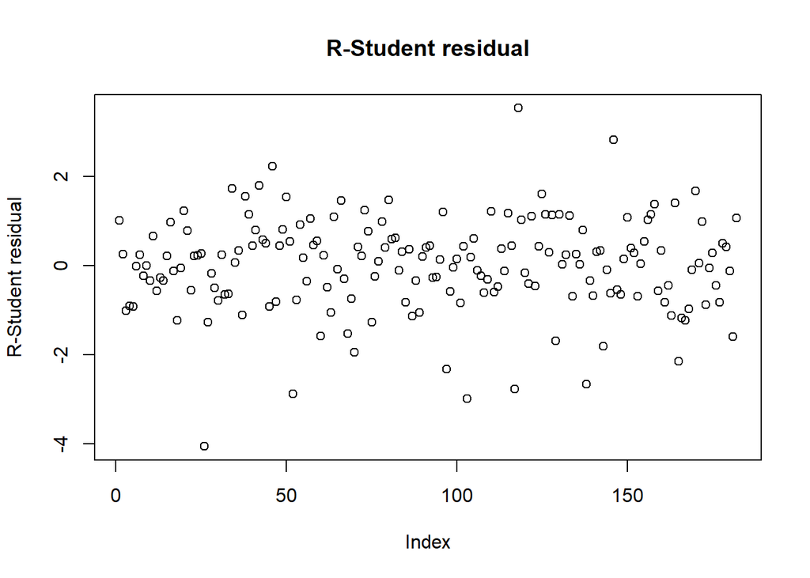

```r
plot(RS,ylab="R-Student residual",main="R-Student residual")
```

Uzyskanie wartości odstających.

```r
RS[abs(RS)==max(abs(RS))]
```

```
##        26
## -4.061307
```

```r
dim(Dane)
```

```
## [1] 182  11
```

```r
dim(Dane)[1]
```

```
## [1] 182
```

```r
0.05/dim(Dane)[1]*2
```

```
## [1] 0.0005494505
```

```r
dim(Dane)[1]-4-1
```

```
## [1] 177
```

```r
qt(0.05/(dim(Dane)[1]*2),(dim(Dane)[1]-4-1))
```

```
## [1] -3.712521
```

```r
(-abs(RS[abs(RS)==max(abs(RS))])<qt(0.05/(dim(Dane)[1]*2),(dim(Dane)[1]-4-1)))
```

```
##   26
## TRUE
```

Dzięki odległości cooka, mogę usunąć wartości odstające i stworzyć nowy model o nazwie “Model_no_outliers”. Kod wykorzystuje funkcję cooks.distance do obliczenia odległości Cooka dla każdego punktu danych. Odległość Cooka jest miarą, jak bardzo punkt danych wpływa na wynik modelu regresji liniowej. Wartość odległości Cooka jest wyznaczana jako iloczyn między zmienną zależną (Life) i skorygowaną estymatą modelu bez tego punktu danych. Wartości odległości Cooka powyżej 1 są uważane za “outliers”, tj. punkty danych, które mają nieproporcjonalnie duży wpływ na wynik modelu. Następnie wykonywane jest wykreślenie wartości odległości Cooka, a następnie tworze nowy model regresji liniowej bez punktów danych, które są outliers. W rezultacie, wynik końcowy jest wynikiem modelu regresji liniowej bez wartości odstających.

```r
(cooks_dis <- cooks.distance(Model))
```

```
##            1            2            3            4            5            6
## 1.084358e-02 1.158679e-04 4.041842e-03 1.033076e-02 2.245975e-03 6.714757e-07
##            7            8            9           10           11           12
## 8.708425e-05 9.492557e-04 1.517303e-08 1.796033e-04 4.433065e-04 7.350522e-04
##           13           14           15           16           17           18
## 1.569365e-04 1.499690e-04 7.685861e-05 1.557227e-03 1.463874e-05 2.546840e-03
##           19           20           21           22           23           24
## 4.061338e-06 2.160770e-03 9.745246e-04 7.601425e-04 6.239910e-05 8.403537e-05
##           25           26           27           28           29           30
## 6.198951e-05 7.059110e-02 5.146900e-03 3.544015e-05 3.074601e-04 3.036962e-03
##           31           32           33           34           35           36
## 5.586022e-04 2.971755e-03 2.307590e-03 4.006873e-03 3.053602e-05 4.743459e-04
##           37           38           39           40           41           42
## 2.171488e-03 3.032421e-02 2.001798e-03 2.217774e-04 1.148955e-03 6.854474e-03
##           43           44           45           46           47           48
## 4.264796e-04 2.664669e-04 6.059988e-03 6.830475e-03 1.129106e-03 1.611891e-04
##           49           50           51           52           53           54
## 1.043956e-03 2.760880e-03 3.194454e-04 1.194298e-01 1.451466e-03 1.059199e-03
##           55           56           57           58           59           60
## 1.317752e-04 1.898576e-04 1.694939e-03 1.352787e-03 5.445132e-03 6.684669e-03
##           61           62           63           64           65           66
## 5.857327e-05 3.574510e-03 2.628266e-03 2.569498e-03 6.967644e-06 2.505006e-02
##           67           68           69           70           71           72
## 3.121076e-04 5.797469e-03 8.629252e-04 6.519839e-02 2.265100e-04 5.534666e-05
##           73           74           75           76           77           78
## 2.819776e-03 2.942617e-01 4.297374e-01 7.765277e-05 3.144929e-05 1.405190e-03
##           79           80           81           82           83           84
## 1.037284e-03 4.876417e-03 3.273077e-04 2.235635e-03 1.675840e-05 2.216640e-04
##           85           86           87           88           89           90
## 2.464354e-03 1.889457e-03 4.743857e-03 1.333189e-04 1.179606e-03 4.804916e-05
##           91           92           93           94           95           96
## 2.710941e-04 5.348596e-03 2.247925e-04 6.615451e-05 2.661073e-05 3.096057e-03
##           97           98           99          100          101          102
## 2.188943e-02 1.773639e-03 2.081422e-06 3.897792e-05 2.152629e-03 5.399223e-04
##          103          104          105          106          107          108
## 3.302102e-02 4.206278e-05 3.321832e-04 1.328257e-05 1.027624e-04 9.295949e-04
##          109          110          111          112          113          114
## 1.390226e-04 1.826201e-02 4.237468e-04 4.554140e-04 2.388011e-03 1.274920e-04
##          115          116          117          118          119          120
## 2.201075e-03 3.247714e-04 6.103057e-02 5.882092e+00 1.626442e-03 3.471825e-05
##          121          122          123          124          125          126
## 2.344821e-03 1.830146e-03 5.171257e-04 2.358737e-04 5.984783e-02 2.495201e-02
##          127          128          129          130          131          132
## 2.016877e-04 2.352226e-03 7.660300e-02 2.083046e-03 8.080530e-07 6.191294e-05
##          133          134          135          136          137          138
## 2.459306e-03 1.123319e-03 8.086594e-05 1.403479e-06 1.259203e-03 2.029298e-02
##          139          140          141          142          143          144
## 1.730489e-04 5.820324e-04 1.073002e-04 1.683776e-04 2.505885e-02 1.529818e-04
##          145          146          147          148          149          150
## 9.258432e-04 1.282444e-02 4.503165e-04 1.881848e-03 8.713101e-05 2.343858e-02
##          151          152          153          154          155          156
## 7.590964e-04 1.035859e-04 1.344452e-03 2.241222e-06 7.078227e-03 1.847264e-03
##          157          158          159          160          161          162
## 2.119699e-03 1.997196e-02 4.627543e-04 1.352773e-04 1.739250e-03 2.357439e-04
##          163          164          165          166          167          168
## 3.401139e-03 3.024241e-02 1.269319e-02 4.242884e-03 1.544484e-02 1.758608e-03
##          169          170          171          172          173          174
## 2.480695e-05 2.067676e-02 5.010622e-06 1.404717e-03 3.072742e-03 6.328392e-06
##          175          176          177          178          179          180
## 1.041605e-04 3.131750e-04 3.372494e-03 2.059599e-04 1.914949e-04 2.645504e-05
##          181          182
## 4.527136e-02 5.129188e-03
```

Tworzenie wykresu

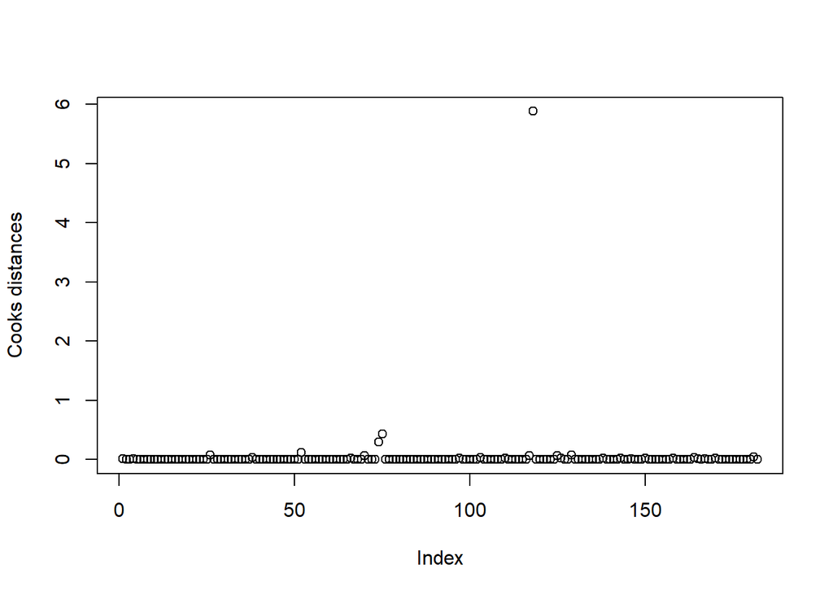

```r
plot(cooks_dis,ylab="Cooks distances")
```

“Model_no_outliers” ma lepsze wyniki niż Model.

```r
Model_no_outliers <-lm(Life~Adult_M+Infant_D+Under_D+Polio+Dipht+GDP+Popl,data=Dane,subset=(cooks_dis<max(cooks_dis)))
summary(Model_no_outliers)
```

```
##
## Call:
## lm(formula = Life ~ Adult_M + Infant_D + Under_D + Polio + Dipht +
##     GDP + Popl, data = Dane, subset = (cooks_dis < max(cooks_dis)))
##
## Residuals:
##      Min       1Q   Median       3Q      Max
## -14.2143  -2.3349   0.1912   2.2708  11.9048
##
## Coefficients:
##               Estimate Std. Error t value Pr(>|t|)
## (Intercept)  7.042e+01  1.714e+00  41.099  < 2e-16 ***
## Adult_M     -4.508e-02  3.816e-03 -11.813  < 2e-16 ***
## Infant_D     2.787e-01  6.307e-02   4.418 1.75e-05 ***
## Under_D     -2.341e-01  5.158e-02  -4.539 1.05e-05 ***
## Polio        4.282e-02  1.824e-02   2.347 0.020060 *
## Dipht        5.017e-02  1.923e-02   2.609 0.009875 **
## GDP          1.194e-04  3.091e-05   3.863 0.000158 ***
## Popl         1.072e-08  1.448e-08   0.740 0.460100
## ---
## Signif. codes:  0 '***' 0.001 '**' 0.01 '*' 0.05 '.' 0.1 ' ' 1
##
## Residual standard error: 4.175 on 173 degrees of freedom
## Multiple R-squared:  0.7349, Adjusted R-squared:  0.7242
## F-statistic: 68.51 on 7 and 173 DF,  p-value: < 2.2e-16
```

Kod tworzy wykres diagnostycznych reszt dla modelu statystycznego. * “par(mfrow=c(2,1))” - ustawia parametr okna, aby rysować dwa wykresy na jednej stronie. * “plot(Model$res, ylab="Residuals", main="Index plot of residuals")" - tworzy wykres indexu reszt dla modelu "Model". * "abline(h=0, col="red")" - dodaje linie na wykresie, reprezentującą wartość 0, w kolorze czerwonym. * "plot(Model$fit, Model$res, xlab="Fitted", ylab="Residuals")" - tworzy wykres reszt, gdzie na osi x jest "Fitted", a na osi y jest "Residuals". * "abline(h=0, col="red")" - dodaje linie na wykresie, reprezentującą wartość 0, w kolorze czerwonym. * "plot(Model_no_outliers$res, ylab=”Residuals”, main=“Index plot of residuals”)” - tworzy wykres indexu reszt dla modelu “Model_no_outliers”. * “abline(h=0, col=”red”)” - dodaje linie na wykresie, reprezentującą wartość 0, w kolorze czerwonym. * “plot(Model_no_outliers$fit, Model_no_outliers$res, xlab=”Fitted”, ylab=“Residuals”)” - tworzy wykres skojarzony reszt, gdzie na osi x jest “Fitted”, a na osi y jest “Residuals”, dla modelu “Model_no_outliers”. * “abline(h=0, col=”red”)” - dodaje linie na wykresie, reprezentującą wartość 0, w kolorze czerwonym

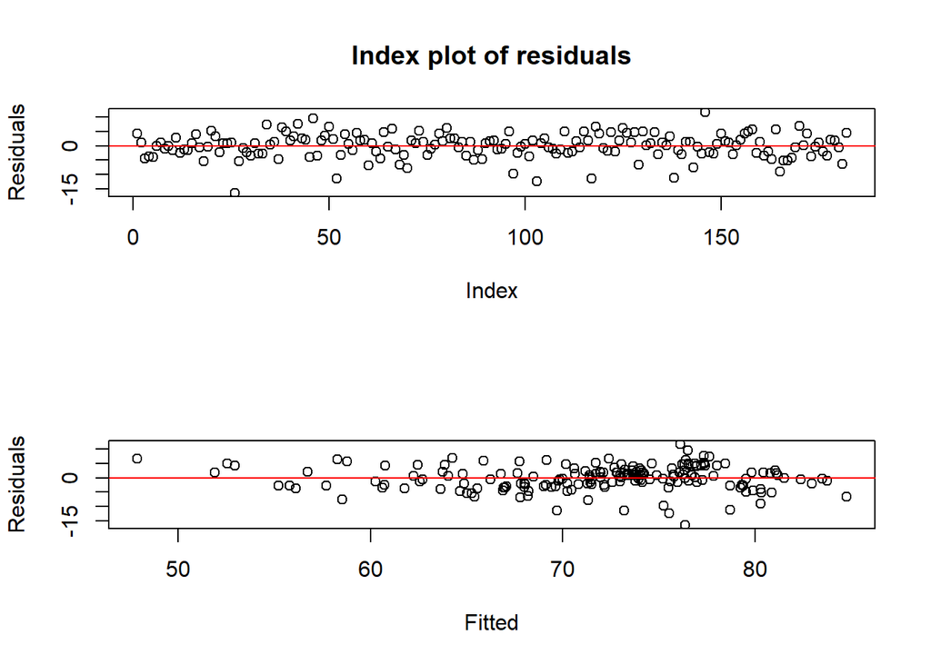

```r
par(mfrow=c(2,1))
plot(Model$res,ylab="Residuals",main="Index plot of residuals")
abline(h=0,col="red")
plot(Model$fit,Model$res,xlab="Fitted",ylab="Residuals")
abline(h=0,col="red")
```

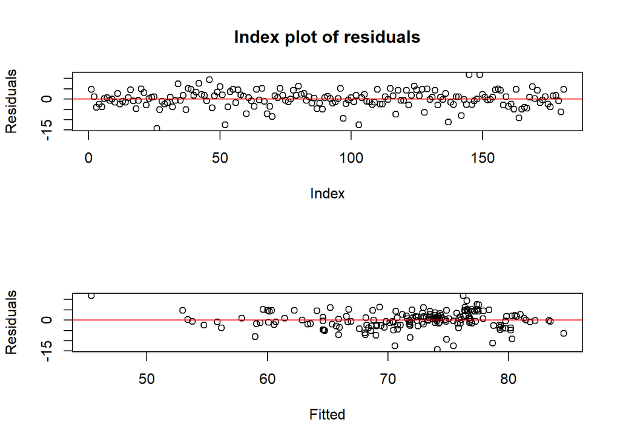

```r
par(mfrow=c(2,1))
plot(Model_no_outliers$res,ylab="Residuals",main="Index plot of residuals")
abline(h=0,col="red")
plot(Model_no_outliers$fit,Model_no_outliers$res,xlab="Fitted",ylab="Residuals")
abline(h=0,col="red")
```

Test rozkładu normalnego zacząłem od graficznego przedstawienia wszystkich zmiennych w modelu. Za pomocą funkcji “boxplot” oraz “qqnorm”. Kod przedstawia. * “boxplot(Dane$Life)" - rysuje wykres typu boxplot, który pokazuje statystyki centralne i rozrzut danych dla zmiennej "Life". * "qqnorm(Dane$”Life” )” - rysuje wykres typu Q-Q plot, który pokazuje, jak bardzo dane odpowiadają rozkładowi normalnemu. * “qqline(Dane$”Life” )” - dodaje linię do wykresu typu Q-Q plot, która pokazuje, jak dane powinny odpowiadać rozkładowi normalnemu.

Jeśli dane są zgodne z rozkładem normalnym, to na wykresie typu Q-Q plot powinny być one rozłożone wokół linii. Jeśli nie są, oznacza to, że dane nie odpowiadają rozkładowi normalnemu. Wykres pudełkowy składa się z osi. Nad osią umieszczony jest prostokąt (pudełko), którego lewy bok jest wyznaczony przez pierwszy kwartyl, zaś prawy bok przez trzeci kwartyl. Szerokość pudełka odpowiada wartości rozstępu ćwiartkowego. Wewnątrz prostokąta znajduje się pionowa linia, określająca wartość mediany. W pierwszym przykładzie można zauważyć, że dane z kolumny “Life” całkiem dobrze wypadają na rozkładzie normalnym.

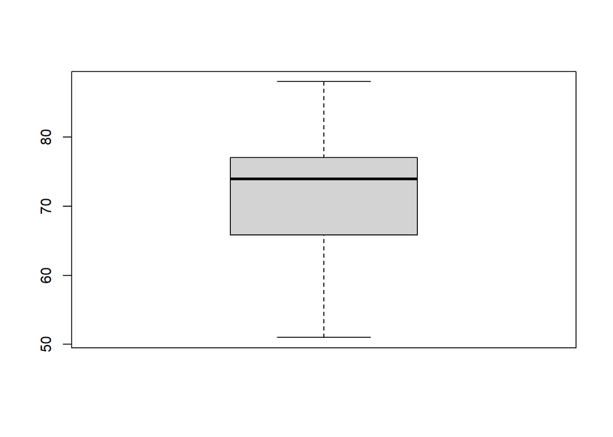

```r
boxplot(Dane$Life)
```

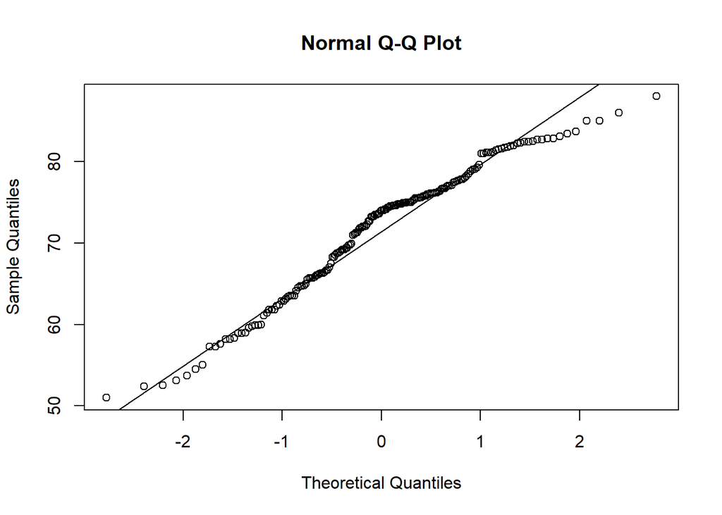

```r
qqnorm(Dane$"Life" )
qqline(Dane$"Life" )
```

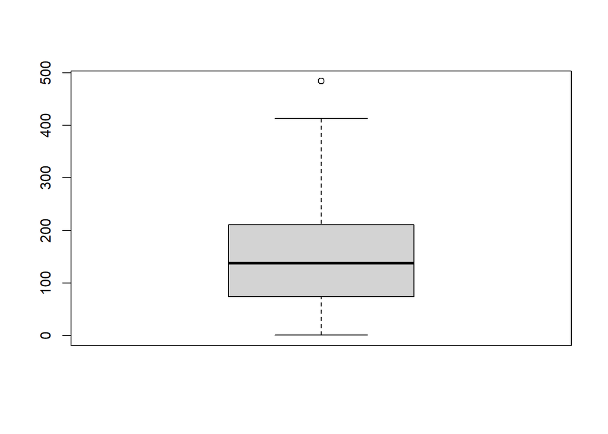

```r
boxplot(Dane$Adult_M)
```

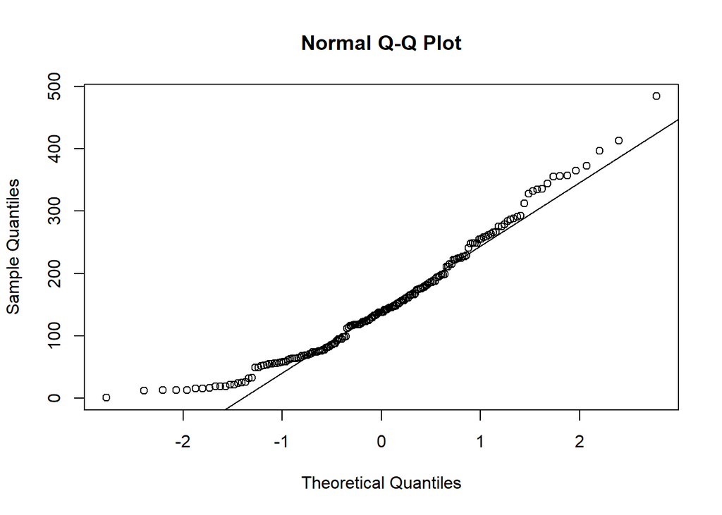

```r
qqnorm(Dane$"Adult_M" )
qqline(Dane$"Adult_M" )
```

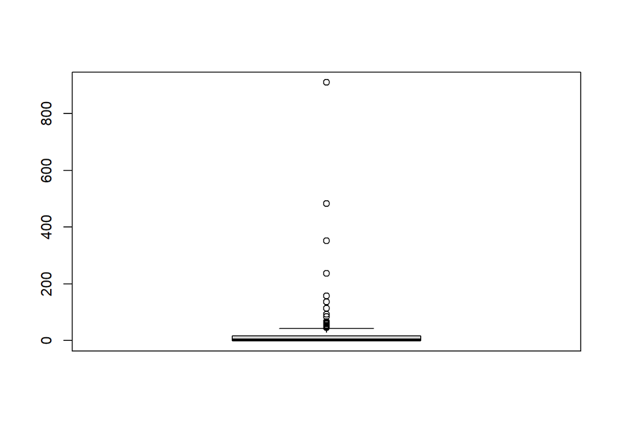

```r
boxplot(Dane$Infant_D)
```

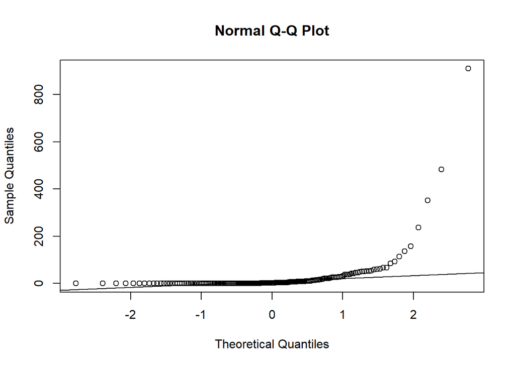

```r
qqnorm(Dane$"Infant_D")
qqline(Dane$"Infant_D")
```

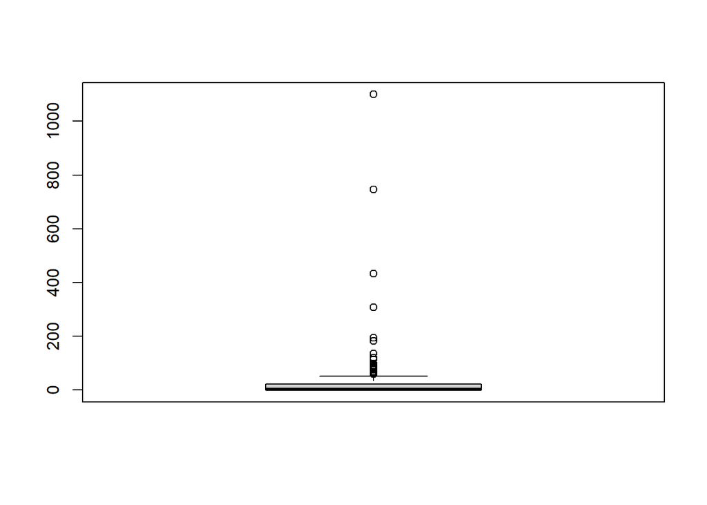

```r
boxplot(Dane$Under_D)
```

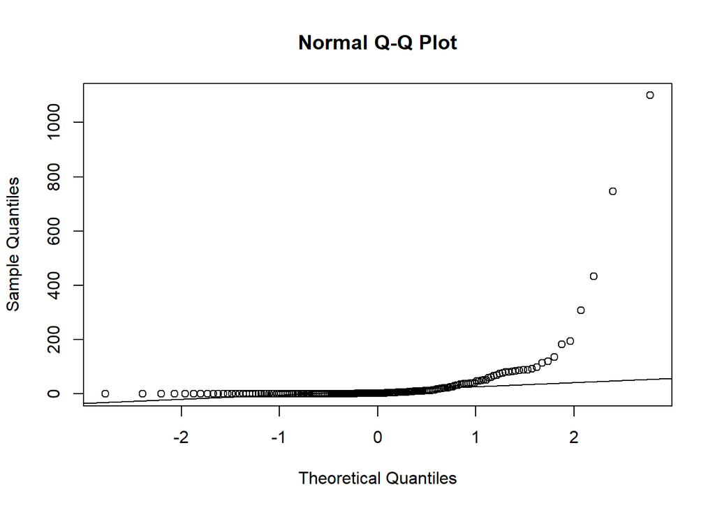

```r
qqnorm(Dane$"Under_D")
qqline(Dane$"Under_D")
```

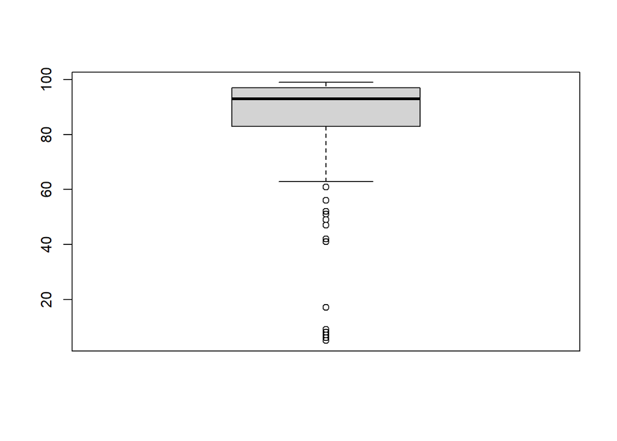

```r
boxplot(Dane$Polio)
```

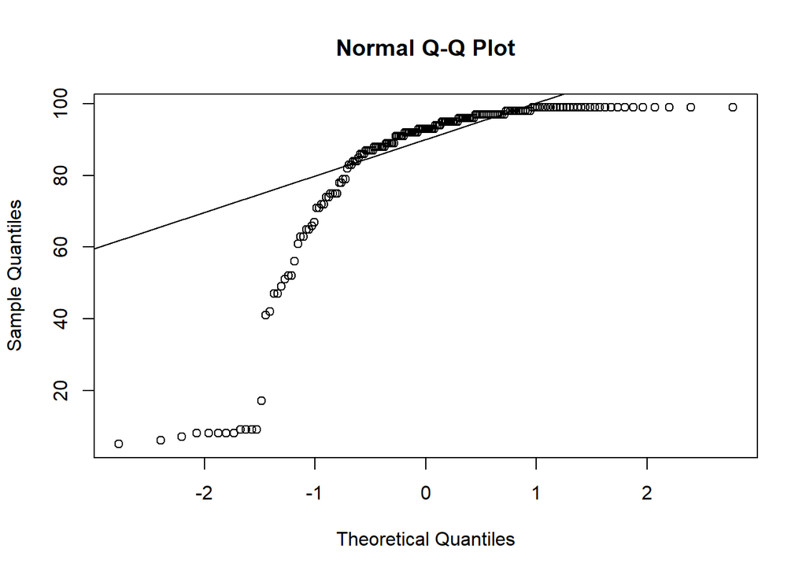

```r
qqnorm(Dane$"Polio")
qqline(Dane$"Polio")
```

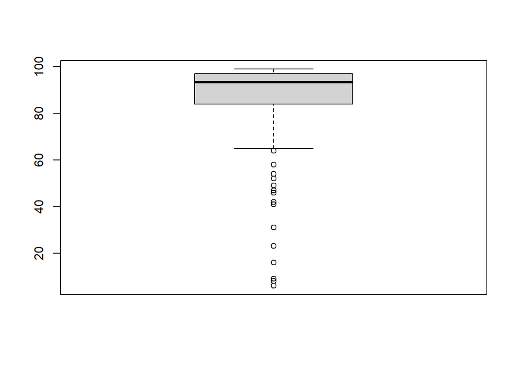

```r
boxplot(Dane$Dipht)
```

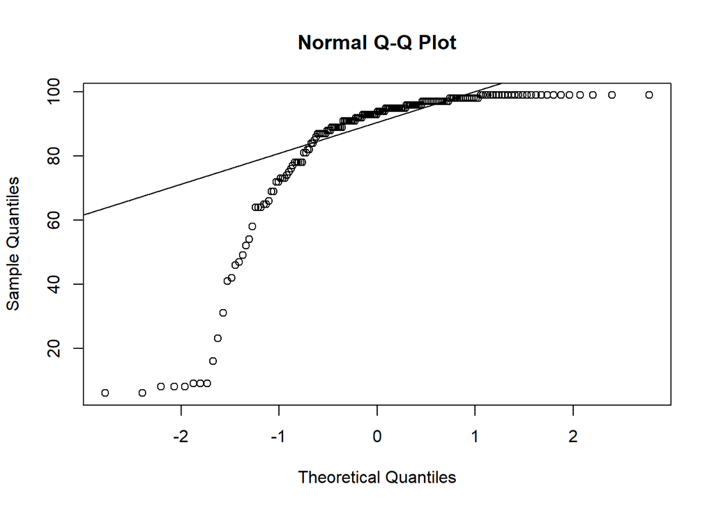

```r
qqnorm(Dane$"Dipht")
qqline(Dane$"Dipht")
```

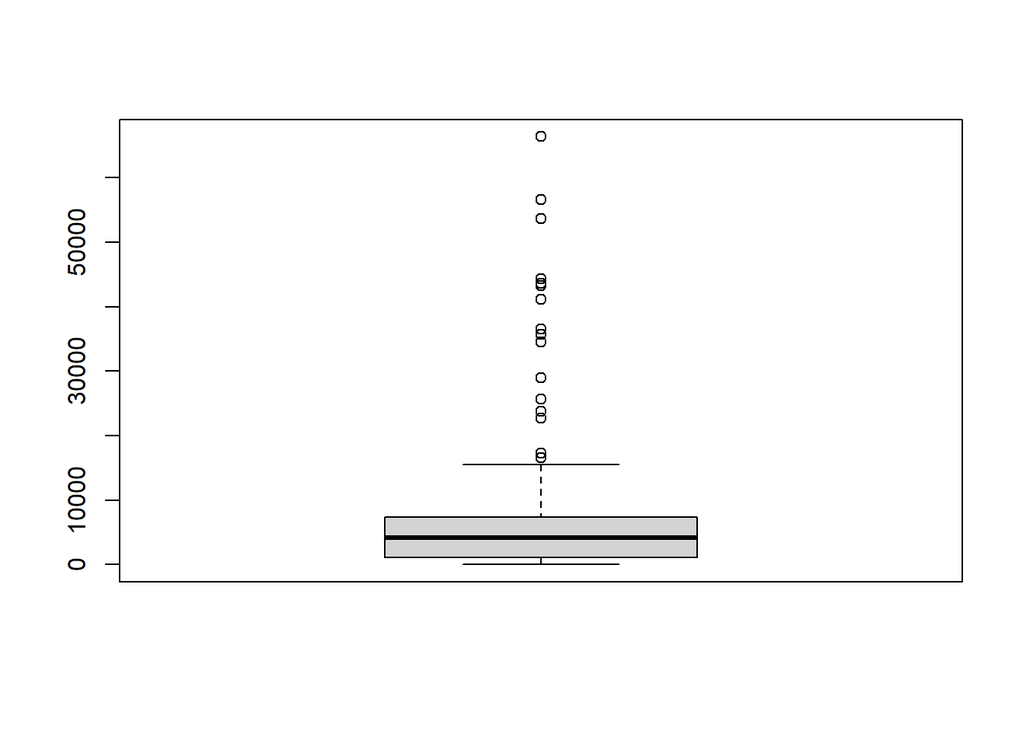

```r
boxplot(Dane$GDP)
```

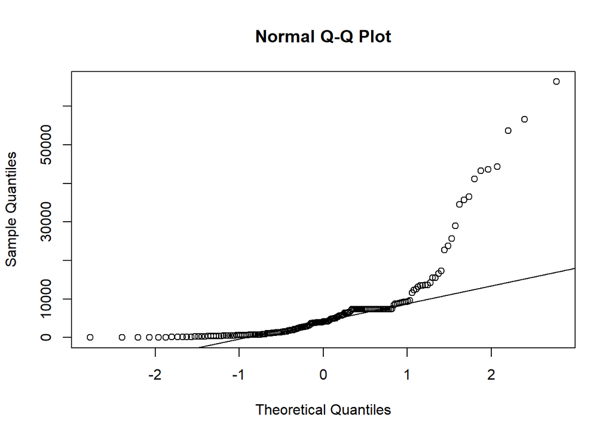

```r
qqnorm(Dane$"GDP")
qqline(Dane$"GDP")
```

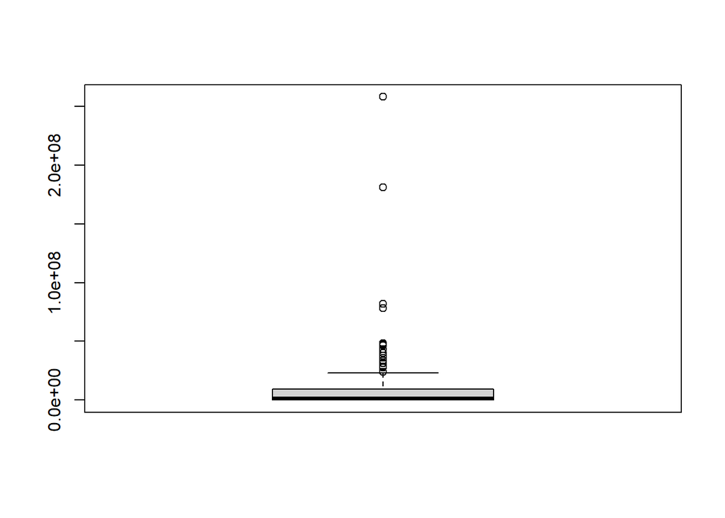

```r
boxplot(Dane$Popl)
```

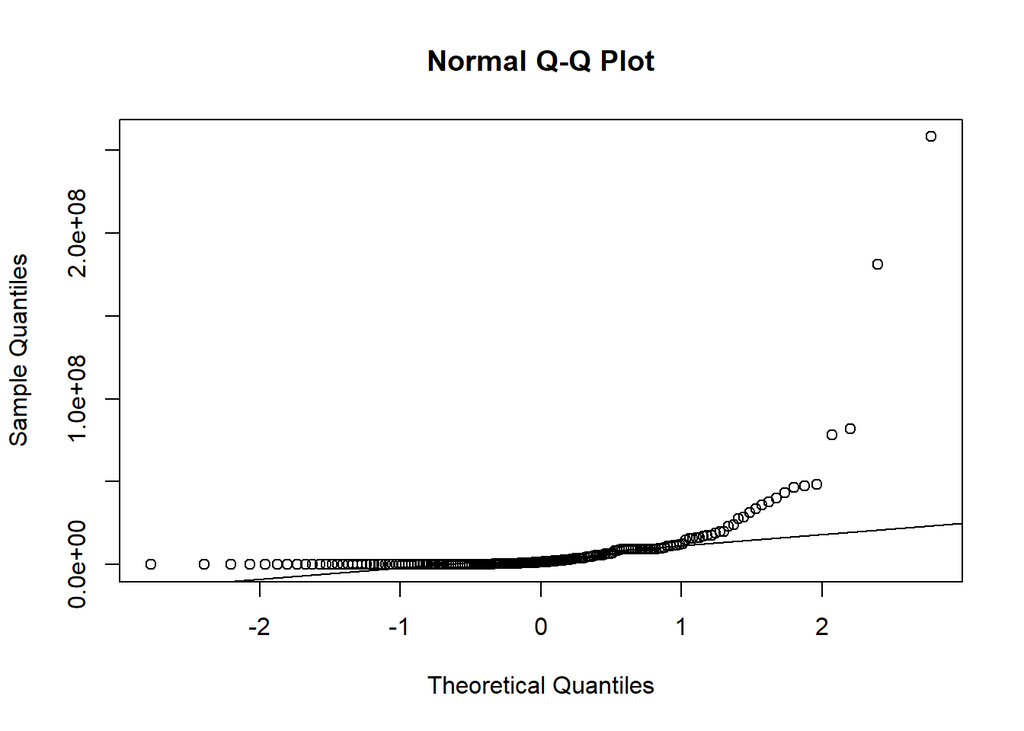

```r
qqnorm(Dane$"Popl")
qqline(Dane$"Popl")
```

Również przedstawiłem graficznie to samo za pomocą pakietu “ggpubr”, oraz funkcji “ggqqplot”. Wykres Q-Q jest rysowany między daną próbą a rozkładem normalnym. Wykreślana jest również 45- stopniowa linia odniesienia, aby ocenić, jak bliskie są wartości próbki rozkładowi normalnemu.

```r
library("ggpubr")
```

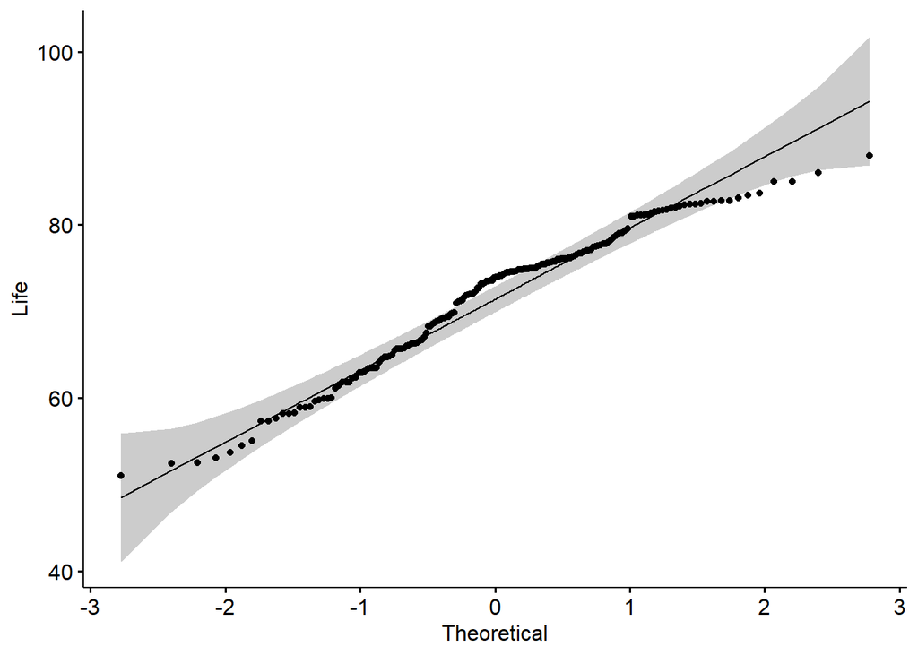

```r
ggqqplot(Dane$Life, ylab = "Life")
```

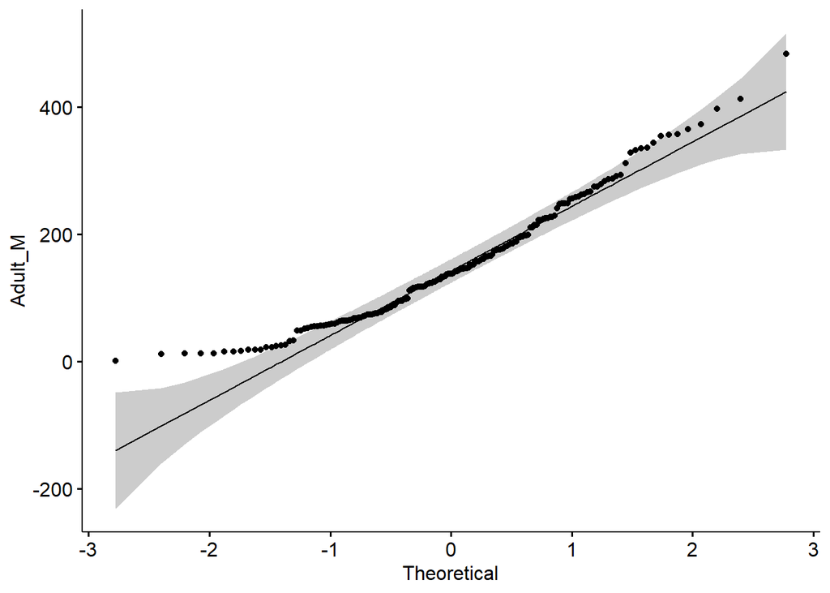

```r
ggqqplot(Dane$Adult_M, ylab = "Adult_M")
```

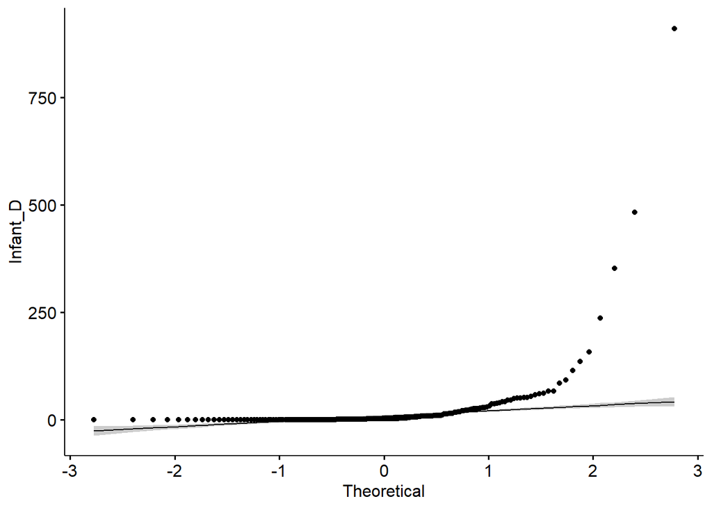

```r
ggqqplot(Dane$Infant_D, ylab = "Infant_D")
```

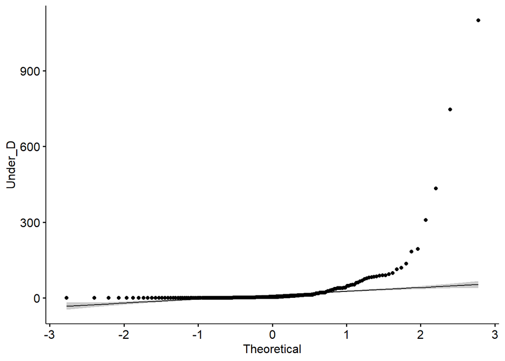

```r
ggqqplot(Dane$Under_D, ylab = "Under_D")
```

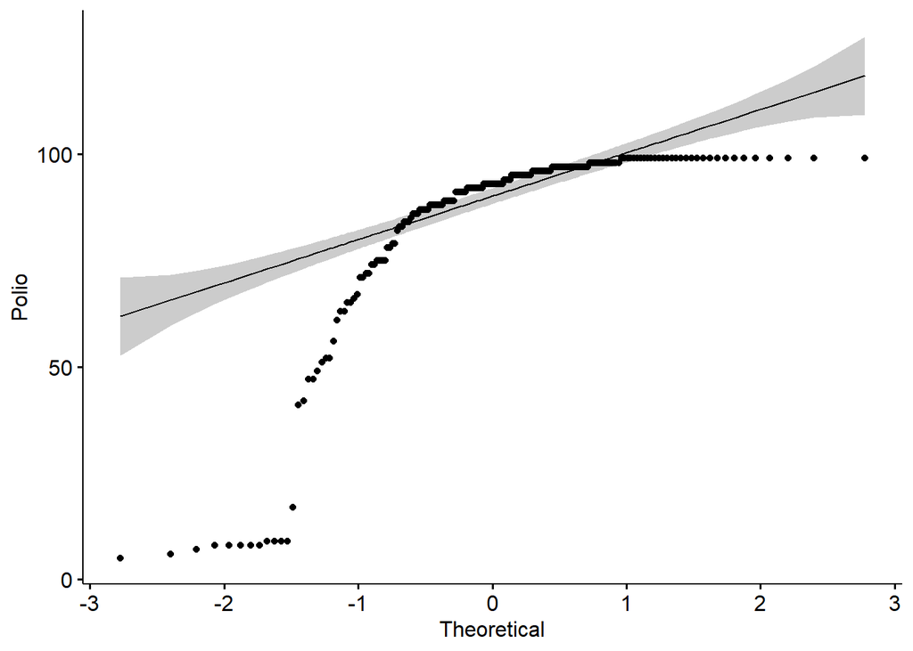

```r
ggqqplot(Dane$Polio, ylab = "Polio")
```

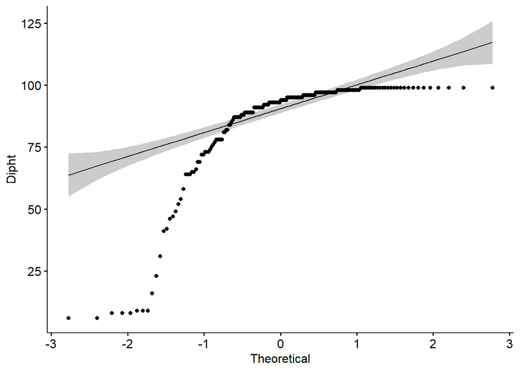

```r
ggqqplot(Dane$Dipht, ylab = "Dipht")
```

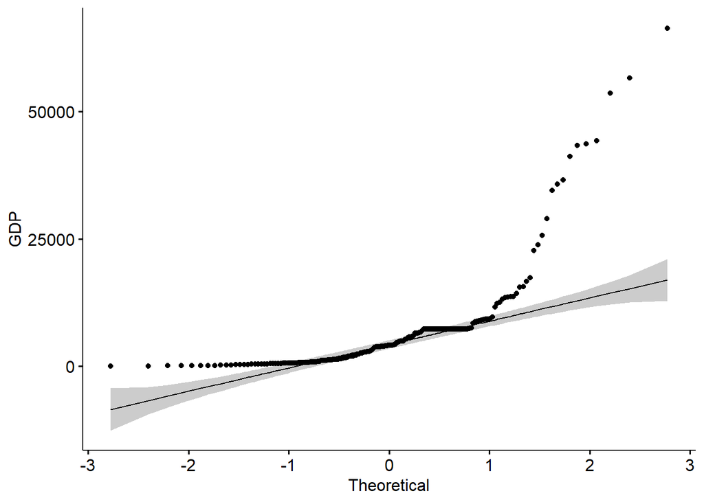

```r
ggqqplot(Dane$GDP, ylab = "GDP")
```